# Robby - Homework 1

```r
library(spatstat)
library(splancs)
library(spatial)
```

# Point Process Homework (Basics)

## Problem 1

What are the two components needed to define a spatial point process?

> 1. Event Locations (where and event did occur)
> 2. Event Space (where an event could occur)

## Problem 2

What are the main components that define a homogeneous Poisson point process?

> 1. Stationarity and a constant intensity parameter Lambda
> 2. Complete Spatial Randomness (events are uniformly distributed over the study region)

## Problem 3

What is the main difference between a homogeneous and heterogeneous point process (pp)?

> The main difference between the two point processes is that the intensity of events within the study region is constant for the homogeneous pp and not constant for the heterogeneous pp.

## Problem 4

Describe the differences between a regular, clustered, and homogeneous (CSR) Poisson pp?

> One can think of the relationship (and the difference between these point patterns) as a spectrum ranging from a regular distribution of points wherein no clustering is observed, moving to CSR in which each event location is uniformly distributed and independent of each other event location, and finally on the other end of the spectrum is clustering, in which event locations are grouped up more than would be random.

## Problem 5

For this problem, I was able to create a plot for each realization using code from Dr. French’s github repo.

### Regular Point Process

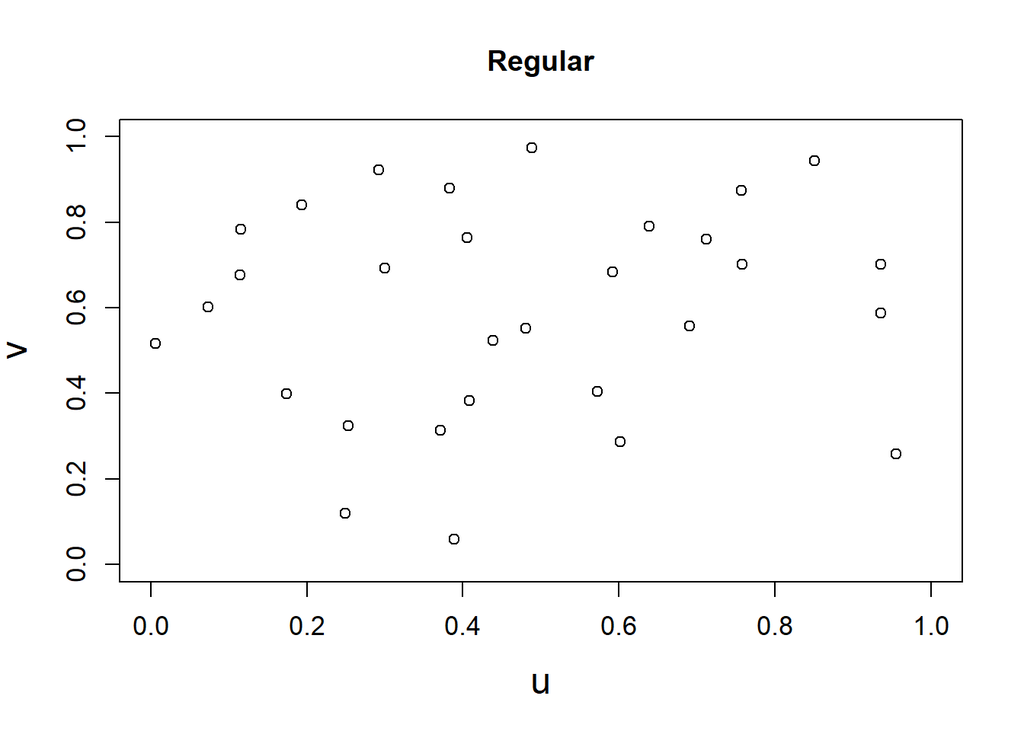

### Clustered Point Process

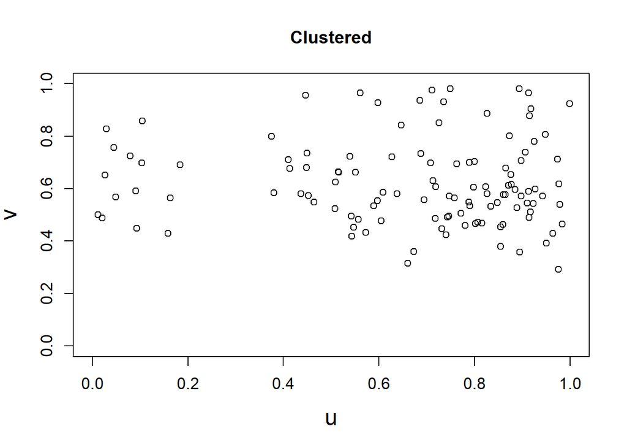

```r
# domain is unit square
domain = cbind(c(0,0,1,1), c(0,1,1,0))


test <- pcp.sim(rho = 5, m = 25, s2 = 0.01, region.poly = domain)
plot(test, xlim = 0:1, ylim = 0:1, xlab = "u", ylab = "v",
     cex.lab = 1.5, cex.axis = 1.1)
title("Clustered")
```

### CSR Poisson Point Process

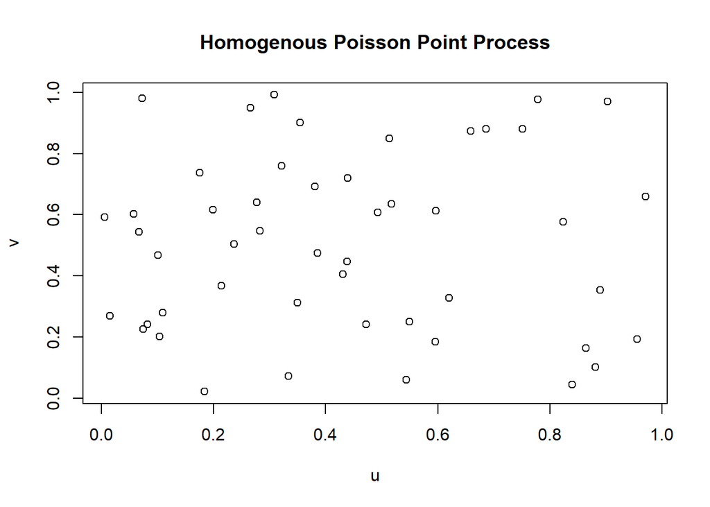

```r
library(spatstat)

poi <- rpoispp(50)
plot(poi$x,poi$y,xlab = "u", ylab = "v", main="Homogenous Poisson Point Process")
```

## Problem 6

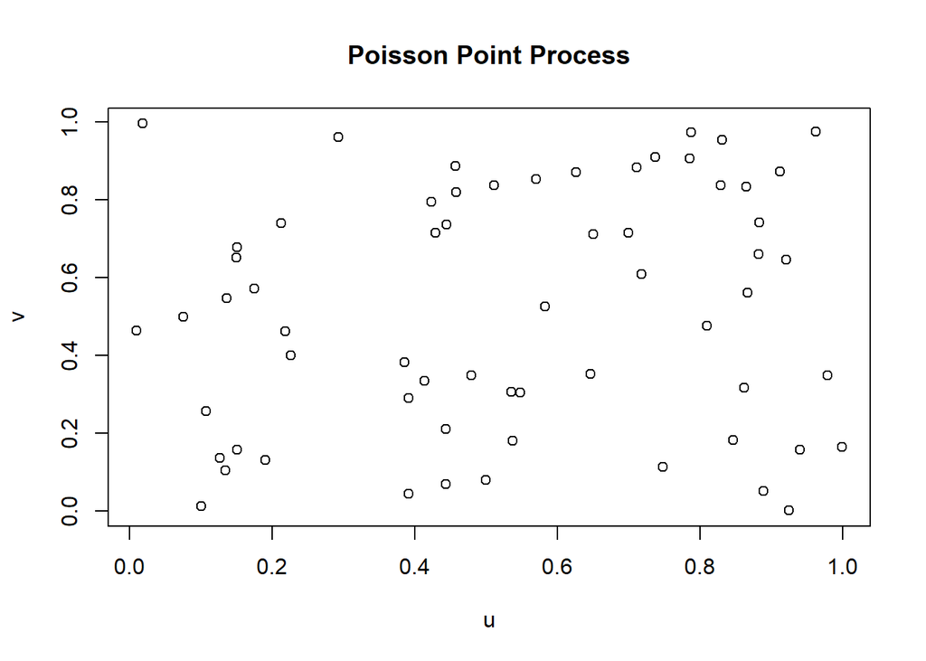

```r
h1 <- rpoispp(50)

plot(h1$x,h1$y, xlab = "u", ylab = "v",main="Poisson Point Process")
```

```r
point_count = length(h1$x)
print("Total Points Generated: ")
```

```
## [1] "Total Points Generated: "
```

```r
print(point_count)
```

```
## [1] 63
```

> The h1 plot shows a seemingly random realization of 63 points. While there is little evidence of overlapping event locations, we can see at least one such pair of events which means this is not a regular plot, and not indicative of clustering. Therefore, it seems the h1 plot could be compatible with CSR.

## Problem 7

```r
rcsr <- function(lambda){
  region = cbind(c(1,0,0,1), c(1,1,0,0))
  N = rpois(500,lambda)
  random_index = sample(1:500, 1)
  points = csr(region,N[random_index])
  wreg = owin(poly = region)
  pp_1 = ppp(x=points[,1],y=points[,2],window = wreg)
  return(pp_1)
}
```

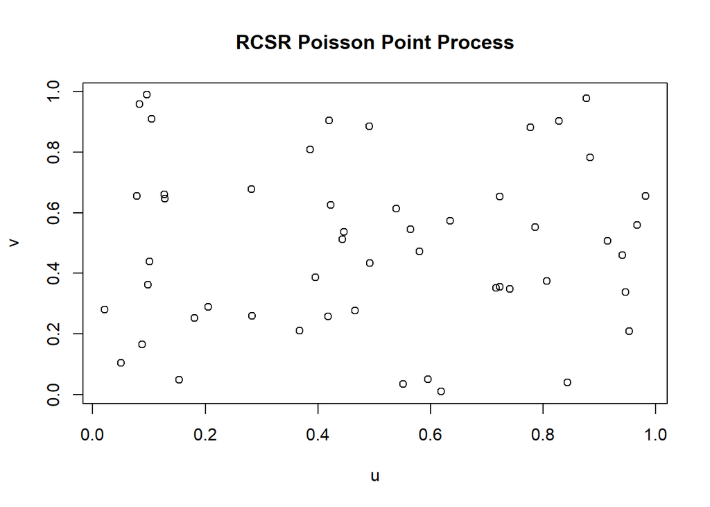

```r
lambda = 50
h2 <- rcsr(lambda)
plot(h2$x,h2$y, xlab = "u", ylab = "v",main="RCSR Poisson Point Process")
```

```r
point_count2 = length(h2$x)
print("Total Points Generated: ")
```

```
## [1] "Total Points Generated: "
```

```r
print(point_count2)
```

```
## [1] 51
```

## Problem 8

> 1. Draw a single data set from the rpoispp function. Use the density function to estimate the intensity function for the simulated data set. Compute the difference between the maximum and minimum estimated intensity values.

```r
dim = 2
df = rpoispp(50)
bx = sd(df$x)*length(df$x)^(-1/(dim+4))
by = sd(df$y)*length(df$y)^(-1/(dim+4))

ix = density(df,sigma = c(bx,by))

ix_min = min(ix$v)
ix_max = max(ix$v)
ix_diff_compare = ix_max - ix_min
ix_mean_compare = mean(ix$v)
print(ix_diff_compare)
```

```
## [1] 70.47447
```

```r
print(ix_mean_compare)
```

```
## [1] 64.75937
```

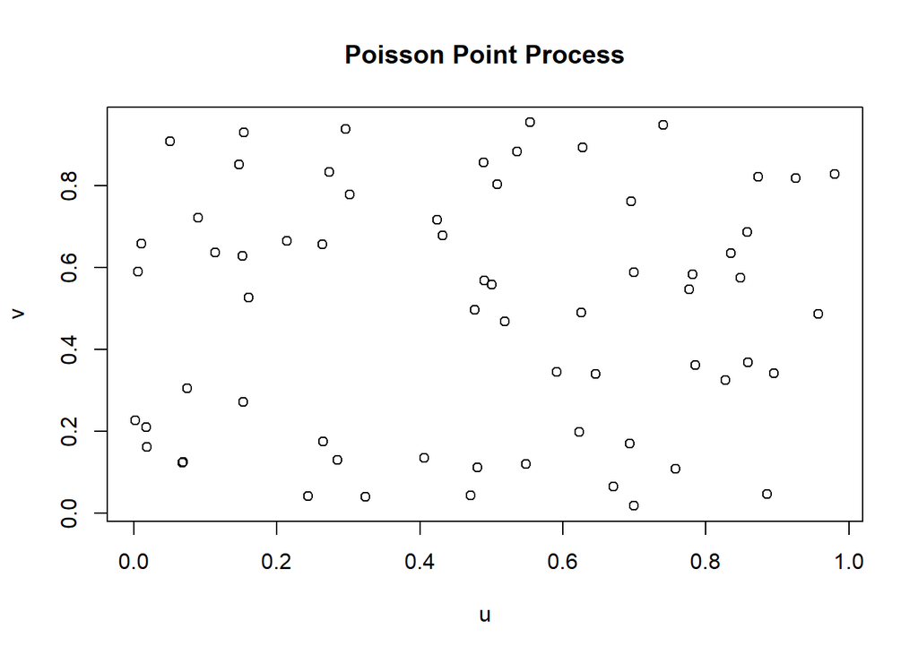

```r
plot(df$x,df$y, xlab = "u", ylab = "v",main="Poisson Point Process")
```

```r
point_count2 = length(df$x)
print("Total Points Generated: ")
```

```
## [1] "Total Points Generated: "
```

```r
print(point_count2)
```

```
## [1] 65
```

> 2. Draw a simulated data set from the ‘rcsr’ function assuming lambda = 50. Use the density function to estimate the intensity function of the simulated data set, and compute the diff between max and min intensity values.

```r
dim = 2
lambda = 50
df2 = rcsr(50)
bx = sd(df2$x)*length(df2$x)^(-1/(dim+4))
by = sd(df2$y)*length(df2$y)^(-1/(dim+4))

ix2 = density(df2,sigma = c(bx,by))

ix_min2 = min(ix2$v)
ix_max2 = max(ix2$v)
ix_diff2 = ix_max2 - ix_min2
print(ix_diff2)
```

```
## [1] 103.8326
```

```r
print(mean(ix2$v))
```

```
## [1] 47.05487
```

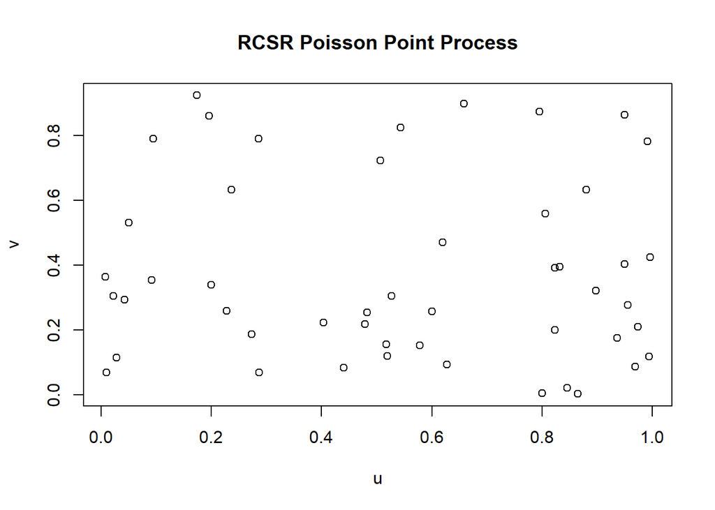

```r
plot(df2$x,df2$y, xlab = "u", ylab = "v",main="RCSR Poisson Point Process")
```

```r
point_count2 = length(df2$x)
print("Total Points Generated: ")
```

```
## [1] "Total Points Generated: "
```

```r
print(point_count2)
```

```
## [1] 49
```

> 3. Repeat previous test 999 times

```r
dim = 2
lambda = 50
result <-  data.frame()
diffs <- data.frame()

for (i in 1:999) {
  df = rcsr(50)
  bx = sd(df$x)*length(df$x)^(-1/(dim+4))
  by = sd(df$y)*length(df$y)^(-1/(dim+4))

  ixr = density(df,sigma = c(bx,by))

  ix_minr = min(ixr$v)
  ix_maxr = max(ixr$v)
  ix_meanr = mean(ixr$v)
  ix_diffr = ix_maxr - ix_minr
  result[i,1] = ix_meanr
  diffs[i,1] = ix_diffr
}

t.test(result,mu=ix_mean_compare)
```

```
##
##  One Sample t-test
##
## data:  result
## t = -61.505, df = 998, p-value < 2.2e-16
## alternative hypothesis: true mean is not equal to 64.75937
## 95 percent confidence interval:
##  49.84064 50.76319
## sample estimates:
## mean of x
##  50.30192
```

> The p-value of the RCSR generated data indicates that we should reject the null hypothesis that the intensities from the RCSR data set are statistically equivalent to the rpois data set. This in turn implies that the RCSR dataset fails to produce a point process that could be classified as CSR. This could be because the rpois data set will have a mean anywhere within the range of a poisson distribution with parameter lambda equal to 50, sometimes above or below 50 by enough to show a statistical difference between the observed means.

## Problem 9

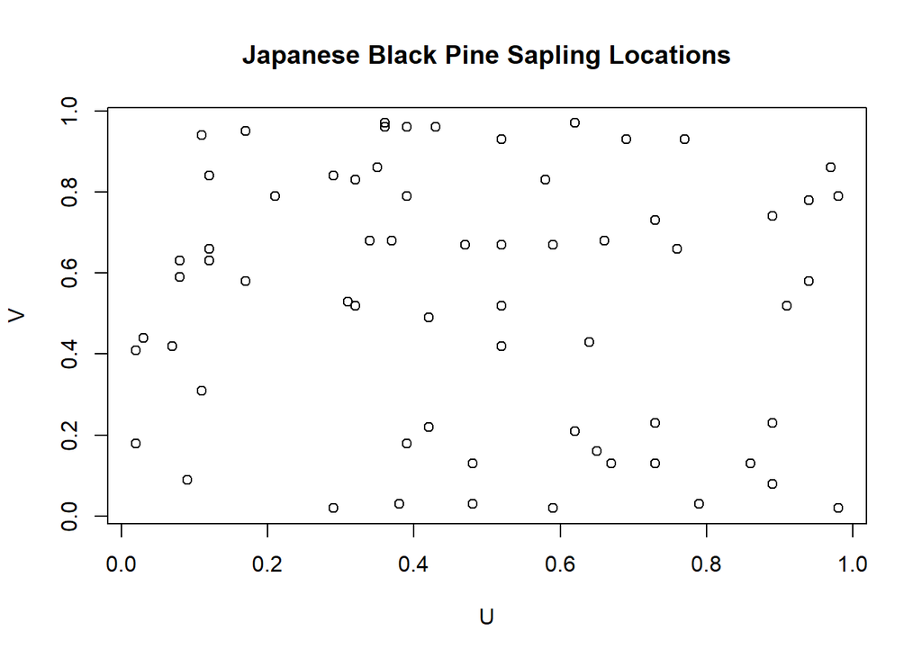

```r
numata_pines <- spatstat.data::japanesepines
plot(numata_pines$x,numata_pines$y,xlab='U',ylab='V',main='Japanese Black Pine Sapling Locations')
```

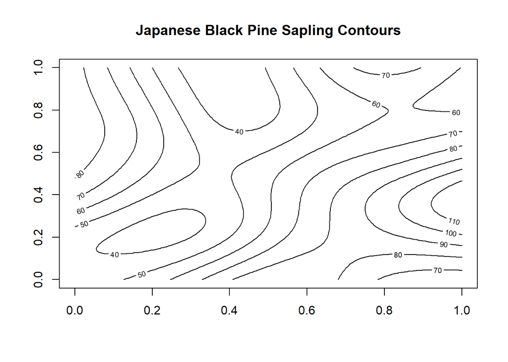

```r
bx = sd(numata_pines$x)*length(numata_pines$x)^(-1/(dim+4))
by = sd(numata_pines$y)*length(numata_pines$y)^(-1/(dim+4))

ix = density(numata_pines,sigma = c(bx,by))
contour(ix$v,main='Japanese Black Pine Sapling Contours')
```

> The observed data appears to be compatible with CSR as the intensity varies and no obvious clustering can be seen, though some overlapping event locations imply the points are not regular either.